# Assignment4

# Problem 1: Using ANN for Covid Sentiment Classification

## Data Manipulation

### Input and Stem Data

```r
library(qdap)
library(data.table)
covid <- fread("Corona_NLP_train.csv", encoding="Latin-1")

covid$OriginalTweet=rm_stopwords(covid$OriginalTweet, stopwords=tm::stopwords("english"), separate=FALSE, strip=TRUE)

covid$OriginalTweet=stemmer(covid$OriginalTweet, warn=FALSE)
```

### Randomize Data and Restrict Results

```r
set.seed(1)
covid.r <- covid[sample(1:nrow(covid)),]
covid.s <- covid.r
covid.s[which(covid.s$Sentiment == "Extremely Positive")]$Sentiment = "Positive"
covid.s[which(covid.s$Sentiment == "Extremely Negative")]$Sentiment = "Negative"

sentiment = c("Negative", "Neutral", "Positive")
# 0 = Negative
# 1 = Neutral
# 2 = Positive
```

```r
covid.s$Sentiment <- as.factor(covid.s$Sentiment)
covid.numeric <- covid.s
labels=as.numeric(unlist(covid.numeric[,"Sentiment"]))-1
covid.numeric$Sentiment <- labels
```

## Prepare Data for ANN

### Create Partitions

```r
covid.train <- covid.numeric[1:26340]
covid.test <- covid.numeric[26341:32925]
covid.validation <- covid.numeric[32926:41157]
```

### Convert Data

```r
library(keras)
library(tensorflow)

text_vectorizer <- layer_text_vectorization(output_mode="tf_idf", ngrams=2, max_tokens=5000)
#covid.train$OriginalTweet <- as.factor(covid.train$OriginalTweet)
text_vectorizer %>% adapt(covid.train$OriginalTweet)

covid.train.dtm = text_vectorizer(covid.train$OriginalTweet)
covid.test.dtm = text_vectorizer(covid.test$OriginalTweet)
covid.val.dtm = text_vectorizer(covid.validation$OriginalTweet)
```

```r
maxInput <- max(max(covid.train.dtm), max(covid.test.dtm), max(covid.val.dtm))
covid.train.dtm.norm <- covid.train.dtm / maxInput$numpy()
covid.test.dtm.norm <- covid.test.dtm / maxInput$numpy()
covid.val.dtm.norm <- covid.val.dtm / maxInput$numpy()

val <- list(covid.val.dtm.norm, covid.validation$Sentiment)
test = list()
test$x = covid.test.dtm.norm
test$y = covid.test$Sentiment
```

## Training, Tuning, and Evaluation of Neural Network Model

### Training

```r
model <- keras_model_sequential()                   %>%
  layer_dense(units = 10, activation = "sigmoid",       # input layer
              input_shape = 5000)                   %>%
  layer_dense(units = 10, activation = "sigmoid")   %>%   # first hidden layer
  layer_dense(units = 10, activation = "sigmoid")   %>%   # second hidden layer
  layer_dense(units = 3, activation = "softmax")          # output layer

model %>% compile(
  optimizer = 'adam',
  loss = 'sparse_categorical_crossentropy',
  metrics = 'accuracy'
)
```

[figure not shown]

#### Inital Results

```r
library(gmodels)

predicted.nums <- as.numeric(model %>% predict(covid.test.dtm.norm) %>% k_argmax())

rmse= function(x, y){
  return ((mean((x - y)^2))^0.5)
}

predicted.labels <- sentiment[predicted.nums + 1]
CrossTable(predicted.labels, covid.test$Sentiment)
```

```
##
##
##    Cell Contents
## |-------------------------|
## |                       N |
## | Chi-square contribution |
## |           N / Row Total |
## |           N / Col Total |
## |         N / Table Total |
## |-------------------------|
##
##
## Total Observations in Table:  6585
##
##
##                  | covid.test$Sentiment
## predicted.labels |         0 |         1 |         2 | Row Total |
## -----------------|-----------|-----------|-----------|-----------|
##         Negative |      2066 |       299 |       531 |      2896 |
##                  |   855.249 |    98.848 |   431.193 |           |
##                  |     0.713 |     0.103 |     0.183 |     0.440 |
##                  |     0.828 |     0.249 |     0.184 |           |
##                  |     0.314 |     0.045 |     0.081 |           |
## -----------------|-----------|-----------|-----------|-----------|
##          Neutral |       183 |       758 |       247 |      1188 |
##                  |   158.523 |  1356.498 |   144.538 |           |
##                  |     0.154 |     0.638 |     0.208 |     0.180 |
##                  |     0.073 |     0.632 |     0.085 |           |
##                  |     0.028 |     0.115 |     0.038 |           |
## -----------------|-----------|-----------|-----------|-----------|
##         Positive |       246 |       142 |      2113 |      2501 |
##                  |   519.469 |   215.662 |   938.249 |           |
##                  |     0.098 |     0.057 |     0.845 |     0.380 |
##                  |     0.099 |     0.118 |     0.731 |           |
##                  |     0.037 |     0.022 |     0.321 |           |
## -----------------|-----------|-----------|-----------|-----------|
##     Column Total |      2495 |      1199 |      2891 |      6585 |
##                  |     0.379 |     0.182 |     0.439 |           |
## -----------------|-----------|-----------|-----------|-----------|
##
##
```

```r
print(paste("RMSE: ", rmse(predicted.nums, covid.test$Sentiment)))
```

```
## [1] "RMSE:  0.777336534635397"
```

### Tuning

```
## 384 total combinations of flags
```

```
## (sampled to 4 combinations)
```

```
## Training run 1/4 (flags = list(1e-04, 1, "sigmoid", 32, 128))
```

```
## Using run directory runs/2023-04-04T05-28-18Z
```

```
##
## > FLAGS = flags(flag_numeric("learning_rate", 0.01),
## +     flag_numeric("units1", 32), flag_numeric("units2", 32), flag_numeric("batch_size",
## +      .... [TRUNCATED]
##
## > library(keras)
##
## > model <- keras_model_sequential() %>% layer_dense(units = FLAGS$units1,
## +     input_shape = 5000, activation = FLAGS$activation_function) %>%
## +    .... [TRUNCATED]
##
## > history <- model %>% compile(loss = "sparse_categorical_crossentropy",
## +     optimizer = optimizer_adam(learning_rate = FLAGS$learning_rate),
## +    .... [TRUNCATED]
##
## > model %>% fit(covid.train.dtm.norm, covid.train$Sentiment,
## +     epochs = 20, batch_size = FLAGS$batch_size, validation_data = val,
## +     verbose  .... [TRUNCATED]
```

```
##
## Run completed: runs/2023-04-04T05-28-18Z
```

```
## Training run 2/4 (flags = list(0.001, 1, "tanh", 64, 32))
```

```
## Using run directory runs/2023-04-04T05-48-58Z
```

```
##
## > FLAGS = flags(flag_numeric("learning_rate", 0.01),
## +     flag_numeric("units1", 32), flag_numeric("units2", 32), flag_numeric("batch_size",
## +      .... [TRUNCATED]
##
## > library(keras)
##
## > model <- keras_model_sequential() %>% layer_dense(units = FLAGS$units1,
## +     input_shape = 5000, activation = FLAGS$activation_function) %>%
## +    .... [TRUNCATED]
##
## > history <- model %>% compile(loss = "sparse_categorical_crossentropy",
## +     optimizer = optimizer_adam(learning_rate = FLAGS$learning_rate),
## +    .... [TRUNCATED]
##
## > model %>% fit(covid.train.dtm.norm, covid.train$Sentiment,
## +     epochs = 20, batch_size = FLAGS$batch_size, validation_data = val,
## +     verbose  .... [TRUNCATED]
```

```
##
## Run completed: runs/2023-04-04T05-48-58Z
```

```
## Training run 3/4 (flags = list(0.1, 1, "sigmoid", 32, 32))
```

```
## Using run directory runs/2023-04-04T06-38-07Z
```

```
##
## > FLAGS = flags(flag_numeric("learning_rate", 0.01),
## +     flag_numeric("units1", 32), flag_numeric("units2", 32), flag_numeric("batch_size",
## +      .... [TRUNCATED]
##
## > library(keras)
##
## > model <- keras_model_sequential() %>% layer_dense(units = FLAGS$units1,
## +     input_shape = 5000, activation = FLAGS$activation_function) %>%
## +    .... [TRUNCATED]
##
## > history <- model %>% compile(loss = "sparse_categorical_crossentropy",
## +     optimizer = optimizer_adam(learning_rate = FLAGS$learning_rate),
## +    .... [TRUNCATED]
##
## > model %>% fit(covid.train.dtm.norm, covid.train$Sentiment,
## +     epochs = 20, batch_size = FLAGS$batch_size, validation_data = val,
## +     verbose  .... [TRUNCATED]
```

```
##
## Run completed: runs/2023-04-04T06-38-07Z
```

```
## Training run 4/4 (flags = list(0.001, 1, "sigmoid", 16, 128))
```

```
## Using run directory runs/2023-04-04T06-54-40Z
```

```
##
## > FLAGS = flags(flag_numeric("learning_rate", 0.01),
## +     flag_numeric("units1", 32), flag_numeric("units2", 32), flag_numeric("batch_size",
## +      .... [TRUNCATED]
##
## > library(keras)
##
## > model <- keras_model_sequential() %>% layer_dense(units = FLAGS$units1,
## +     input_shape = 5000, activation = FLAGS$activation_function) %>%
## +    .... [TRUNCATED]
##
## > history <- model %>% compile(loss = "sparse_categorical_crossentropy",
## +     optimizer = optimizer_adam(learning_rate = FLAGS$learning_rate),
## +    .... [TRUNCATED]
##
## > model %>% fit(covid.train.dtm.norm, covid.train$Sentiment,
## +     epochs = 20, batch_size = FLAGS$batch_size, validation_data = val,
## +     verbose  .... [TRUNCATED]
```

```
##
## Run completed: runs/2023-04-04T06-54-40Z
```

#### Tuning Results

```r
runs=runs[order(runs$metric_val_accuracy, decreasing=TRUE),]

view_run(runs$run_dir[1])
```

```
## starting httpd help server ... done
```

The best model had the following hyperparams:  
learning_rate: 0.001  
first hidden layer: 16 units  
second hidden layer: 128 units  
batch_size: 1  
activation function: sigmoid

It seems as though the best model only slightly overfits, having a training accuracy of 80.4% and validation accuracy of 74.6%, and a training loss of .54 and validation loss of .64. The model could be better, but it could also be a lot worse, too.

After 20 epochs, the validation loss is still very slightly decreasing, although there doesn’t seem to be a noticeable decrease specifically from epoch 19 to 20.

```r
train.matrix <- as.matrix(covid.train.dtm.norm)
val.matrix <- as.matrix(covid.val.dtm.norm)

full.train <- rbind(train.matrix, val.matrix)
full.labels <- append(covid.train$Sentiment, covid.validation$Sentiment)
```

### Evaluation

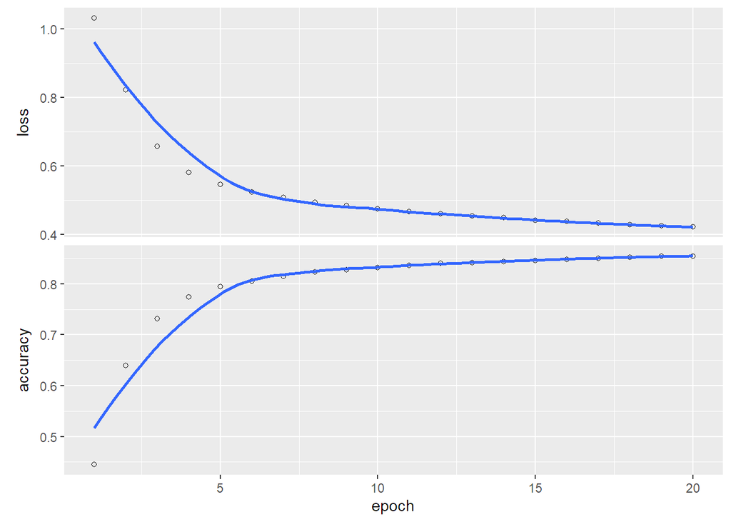

```r
best_model <- keras_model_sequential()              %>%
  layer_dense(units = 16, activation = "sigmoid",       # input layer and first hidden layer
              input_shape = 5000)                   %>%
  layer_dense(units = 128, activation = "sigmoid")   %>%   # second hidden layer
  layer_dense(units = 3, activation = "softmax")          # output layer

best_model %>% compile(
  optimizer = optimizer_adam(learning_rate = 0.001),
  loss = 'sparse_categorical_crossentropy',
  metrics = 'accuracy'
)

set.seed(1)

history <- best_model %>% fit(full.train, full.labels, epochs = 20, batch_size = 1)
plot(history)
```

#### Evaluation Results

```r
predicted.nums <- as.numeric(best_model %>% predict(covid.test.dtm.norm) %>% k_argmax())
res = predicted.nums == covid.test$Sentiment

predicted.labels <- sentiment[predicted.nums + 1]
actual.nums <- covid.test$Sentiment
actual.labels <- sentiment[actual.nums + 1]

ctable <- CrossTable(predicted.labels, actual.labels)
```

```
##
##
##    Cell Contents
## |-------------------------|
## |                       N |
## | Chi-square contribution |
## |           N / Row Total |
## |           N / Col Total |
## |         N / Table Total |
## |-------------------------|
##
##
## Total Observations in Table:  6585
##
##
##                  | actual.labels
## predicted.labels |  Negative |   Neutral |  Positive | Row Total |
## -----------------|-----------|-----------|-----------|-----------|
##         Negative |      1986 |       192 |       377 |      2555 |
##                  |  1070.366 |   160.456 |   494.423 |           |
##                  |     0.777 |     0.075 |     0.148 |     0.388 |
##                  |     0.796 |     0.160 |     0.130 |           |
##                  |     0.302 |     0.029 |     0.057 |           |
## -----------------|-----------|-----------|-----------|-----------|
##          Neutral |       205 |       834 |       222 |      1261 |
##                  |   155.741 |  1590.982 |   198.637 |           |
##                  |     0.163 |     0.661 |     0.176 |     0.191 |
##                  |     0.082 |     0.696 |     0.077 |           |
##                  |     0.031 |     0.127 |     0.034 |           |
## -----------------|-----------|-----------|-----------|-----------|
##         Positive |       304 |       173 |      2292 |      2769 |
##                  |   529.237 |   217.542 |   952.964 |           |
##                  |     0.110 |     0.062 |     0.828 |     0.421 |
##                  |     0.122 |     0.144 |     0.793 |           |
##                  |     0.046 |     0.026 |     0.348 |           |
## -----------------|-----------|-----------|-----------|-----------|
##     Column Total |      2495 |      1199 |      2891 |      6585 |
##                  |     0.379 |     0.182 |     0.439 |           |
## -----------------|-----------|-----------|-----------|-----------|
##
##
```

```r
print(paste("RMSE: ", rmse(predicted.nums, covid.test$Sentiment)))
```

```
## [1] "RMSE:  0.730712511516993"
```

### Precision and Recall

```r
t <- ctable$t
pr <- data.frame(
  "True_Positive" = c(0, 0, 0),
  "True_Negative" = c(0, 0, 0),
  "False_Positive" = c(0, 0, 0),
  "False_Negative" = c(0, 0, 0),
  "Precision" = c(0, 0, 0),
  "Recall" = c(0, 0, 0)
)

row.names(pr) <- sentiment

i <- 1
while(i <= 3){
  pr$True_Positive[i] <- t[i, i]
  pr$False_Positive[i] <- sum(t[i, -i])
  pr$True_Negative[i] <- sum(t[-i, -i])
  pr$False_Negative[i] <- sum(t[-i, i])
  pr$Precision[i] <- pr$True_Positive[i] / (pr$True_Positive[i] + pr$False_Positive[i])
  pr$Recall[i] <- pr$True_Positive[i] / (pr$True_Positive[i] + pr$False_Negative[i])
  i <- i + 1
}

print(pr)
```

```
##          True_Positive True_Negative False_Positive False_Negative Precision
## Negative          1986          3521            569            509 0.7772994
## Neutral            834          4959            427            365 0.6613799
## Positive          2292          3217            477            599 0.8277356
##             Recall
## Negative 0.7959920
## Neutral  0.6955796
## Positive 0.7928053
```

The Naive Bayes model had the following Precision and Recall values:

Negative Precision: 0.726752  
Negative Recall: 0.6900192

Neutral Precision: 0.553553  
Neutral Recall: 0.7026144

Positive Precision: 0.7576761  
Positive Recall: 0.7038591

# Problem 2: Predicting Bike Sharing Demand

## Data Exploration

### Data Summary

```r
bike <- read.csv("bike.csv", header = T)
str(bike)
```

```
## 'data.frame':    10886 obs. of  12 variables:
##  $ datetime  : chr  "2011-01-01 00:00:00" "2011-01-01 01:00:00" "2011-01-01 02:00:00" "2011-01-01 03:00:00" ...
##  $ season    : int  1 1 1 1 1 1 1 1 1 1 ...
##  $ holiday   : int  0 0 0 0 0 0 0 0 0 0 ...
##  $ workingday: int  0 0 0 0 0 0 0 0 0 0 ...
##  $ weather   : int  1 1 1 1 1 2 1 1 1 1 ...
##  $ temp      : num  9.84 9.02 9.02 9.84 9.84 ...
##  $ atemp     : num  14.4 13.6 13.6 14.4 14.4 ...
##  $ humidity  : int  81 80 80 75 75 75 80 86 75 76 ...
##  $ windspeed : num  0 0 0 0 0 ...
##  $ casual    : int  3 8 5 3 0 0 2 1 1 8 ...
##  $ registered: int  13 32 27 10 1 1 0 2 7 6 ...
##  $ count     : int  16 40 32 13 1 1 2 3 8 14 ...
```

```r
summary(bike)
```

```
##    datetime             season         holiday          workingday
##  Length:10886       Min.   :1.000   Min.   :0.00000   Min.   :0.0000
##  Class :character   1st Qu.:2.000   1st Qu.:0.00000   1st Qu.:0.0000
##  Mode  :character   Median :3.000   Median :0.00000   Median :1.0000
##                     Mean   :2.507   Mean   :0.02857   Mean   :0.6809
##                     3rd Qu.:4.000   3rd Qu.:0.00000   3rd Qu.:1.0000
##                     Max.   :4.000   Max.   :1.00000   Max.   :1.0000
##     weather           temp           atemp          humidity
##  Min.   :1.000   Min.   : 0.82   Min.   : 0.76   Min.   :  0.00
##  1st Qu.:1.000   1st Qu.:13.94   1st Qu.:16.66   1st Qu.: 47.00
##  Median :1.000   Median :20.50   Median :24.24   Median : 62.00
##  Mean   :1.418   Mean   :20.23   Mean   :23.66   Mean   : 61.89
##  3rd Qu.:2.000   3rd Qu.:26.24   3rd Qu.:31.06   3rd Qu.: 77.00
##  Max.   :4.000   Max.   :41.00   Max.   :45.45   Max.   :100.00
##    windspeed          casual         registered        count
##  Min.   : 0.000   Min.   :  0.00   Min.   :  0.0   Min.   :  1.0
##  1st Qu.: 7.002   1st Qu.:  4.00   1st Qu.: 36.0   1st Qu.: 42.0
##  Median :12.998   Median : 17.00   Median :118.0   Median :145.0
##  Mean   :12.799   Mean   : 36.02   Mean   :155.6   Mean   :191.6
##  3rd Qu.:16.998   3rd Qu.: 49.00   3rd Qu.:222.0   3rd Qu.:284.0
##  Max.   :56.997   Max.   :367.00   Max.   :886.0   Max.   :977.0
```

The dataset contains 10886 observations

### Variable types

- `datetime`: continuous
- `season`: nominal categorical
- `holiday`: nominal categorical
- `workingday`: nominal categorical
- `weather`: ordinal discrete
- `temp`: continuous
- `atemp`: continuous
- `humidity`: continuous
- `windspeed`: continuous
- `casual`: continuous
- `registered`: continuous
- `count`: continuous

### Missing Values:

```r
i <- 1
while(i <= ncol(bike)){
  bike[which(is.na(bike[i])),]
  i <- i + 1
}
```

There are no missing values

### Histogram

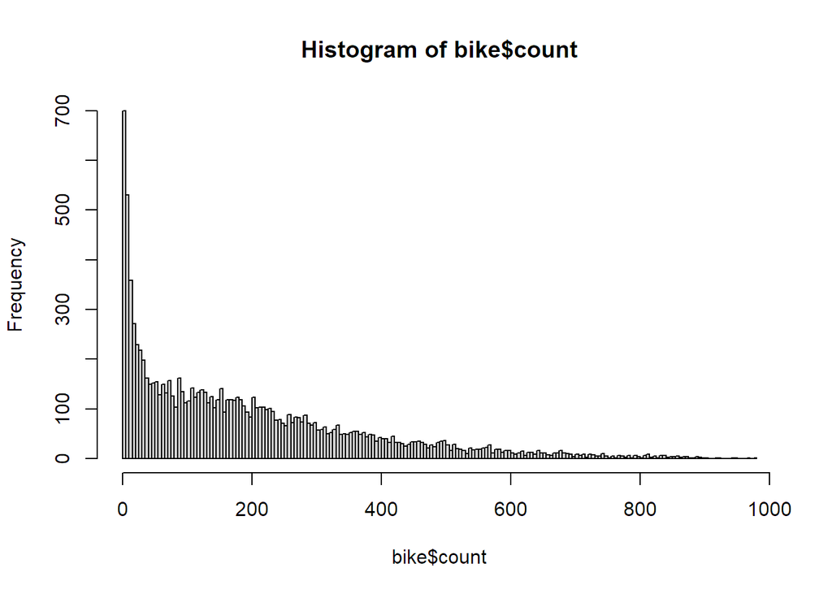

```r
hist(bike$count, breaks = 250)
```

## Feature Engineering

### Remove Columns

```r
bike$registered <- NULL
bike$casual <- NULL
```

### Normalize Count

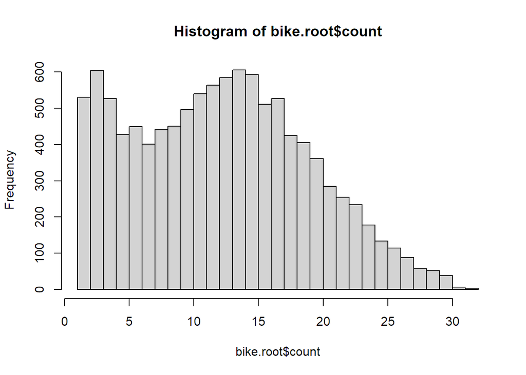

```r
bike.root <- bike
bike.root$count <- bike.root$count^0.5 # calculate square root of count
hist(bike.root$count, breaks = 32)
```

### Extract Date

```r
library(lubridate)
timeDates <- as.POSIXlt(bike.root$datetime)     # get datetime objects as POSIXlt objects
bike.date <- bike.root
bike.date$dayofmonth <- unclass(timeDates)$mday # unclass the POSIXlt object into its columns
bike.date$year <- unclass(timeDates)$year
bike.date$dayofweek <- unclass(timeDates)$wday
bike.date$month <- unclass(timeDates)$mon
bike.date$hour <- unclass(timeDates)$hour
```

### Convert Time to Circular

#### Convert Values

```r
bike.date.trig <- bike.date
bike.date.trig$xmonth <- cos(2 * pi * bike.date.trig$month / max(bike.date.trig$month))
bike.date.trig$ymonth <- sin(2 * pi * bike.date.trig$month / max(bike.date.trig$month))

bike.date.trig$xday <- cos(2 * pi * bike.date.trig$dayofweek / max(bike.date.trig$dayofweek))
bike.date.trig$yday <- sin(2 * pi * bike.date.trig$dayofweek / max(bike.date.trig$dayofweek))

bike.date.trig$xhour <- cos(2 * pi * bike.date.trig$hour / max(bike.date.trig$hour))
bike.date.trig$yhour <- sin(2 * pi * bike.date.trig$hour / max(bike.date.trig$hour))

bike.date.trig$xseason <- cos(2 * pi * bike.date.trig$season / max(bike.date.trig$season))
bike.date.trig$yseason <- sin(2 * pi * bike.date.trig$season / max(bike.date.trig$season))

bike.date.trig$dayofmonth <- as.numeric(bike.date.trig$dayofmonth)
```

#### Remove Original Time Cols

```r
bike.date.trig$month <- NULL
bike.date.trig$dayofweek <- NULL
bike.date.trig$hour <- NULL
bike.date.trig$season <- NULL
bike.date.trig$datetime <- NULL
```

All categorical variables are either already encoded (`holiday` and `workingday`) or have been converted to a numeric form (`season`). Weather is ordinal and therefore shouldn’t be one-hot encoded.

## Create Partitions

### Test Partition

```r
library(caret)
set.seed(1)
bike.rand <- bike.date.trig[sample(1:nrow(bike.date.trig)),]

set.seed(1)
inTrain <- createDataPartition(bike.rand$count, p = 0.9, list=F)

bike.trainval <- bike.rand[inTrain,]
bike.test <- bike.rand[-inTrain,]
```

### Validation Partition

```r
set.seed(1)

inTrain <- createDataPartition(bike.trainval$count, p = 0.9, list=F)

bike.train <- bike.trainval[inTrain,]
bike.val <- bike.trainval[-inTrain,]
```

## Scale Data

```r
train.means <- colMeans(bike.train)
train.sds <- apply(bike.train, 2, sd)

z_score <- function(x, df){
  column_num <- which(colSums(df == x) == length(x)) # determine which column we are applying function to
  mean <- train.means[column_num] # retrieve mean of that column
  sd <- train.sds[column_num]     # retrieve sd of that column
  z <- (x - mean)/sd
  return(z)
}
```

### Train Data

```r
bike.train.scale <- bike.train
bike.train.scale <- as.data.frame(apply(bike.train.scale, 2, function(x) z_score(x, bike.train)))
bike.train.scale$holiday <- bike.train$holiday
bike.train.scale$workingday <- bike.train$workingday
bike.train.scale$count <- bike.train$count
```

### Validation Data

```r
bike.val.scale <- bike.val
bike.val.scale <- as.data.frame(apply(bike.val.scale, 2, function(x) z_score(x, bike.val)))
bike.val.scale$holiday <- bike.val$holiday
bike.val.scale$workingday <- bike.val$workingday
bike.val.scale$count <- bike.val$count
```

### Test Data

```r
bike.test.scale <- bike.test
bike.test.scale <- as.data.frame(apply(bike.test.scale, 2, function(x) z_score(x, bike.test)))
bike.test.scale$holiday <- bike.test$holiday
bike.test.scale$workingday <- bike.test$workingday
bike.test.scale$count <- bike.test$count
```

## Create ANN Model

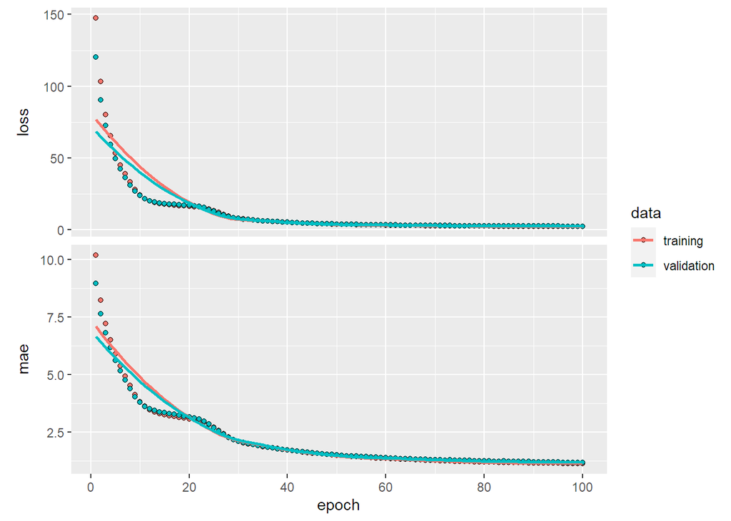

```r
library(keras)
library(tensorflow)

count <- 8

train.x <- as.matrix(bike.train.scale[,-count])
train.y <- as.matrix(bike.train.scale[,count])

val <- list(as.matrix(bike.val.scale[,-count]), as.matrix(bike.val.scale[,count]))

model <- keras_model_sequential()                 %>%
  layer_dense(32, activation = "sigmoid",             # input and first hidden layer
              input_shape = ncol(train.x))        %>%
  layer_dense(units = 16, activation = "sigmoid") %>% # second hidden layer
  layer_dense(units = 1, activation = "relu")         # output layer

model %>% compile(
  optimizer = 'adam',
  loss = 'mse',
  metrics = 'mae'
)

set.seed(1)

history <- model %>% fit(train.x, train.y, epochs = 100, validation_data=val, batch_size = 64)
plot(history)
```

### Tune Hyperparameters

```
## 576 total combinations of flags
```

```
## (sampled to 6 combinations)
```

```
## Training run 1/6 (flags = list(0.1, 1, "tanh", 128, 16))
```

```
## Using run directory runs/2023-04-04T07-33-20Z
```

```
##
## > FLAGS = flags(flag_numeric("learning_rate", 0.01),
## +     flag_numeric("units1", 32), flag_numeric("units2", 32), flag_numeric("batch_size",
## +      .... [TRUNCATED]
##
## > library(keras)
##
## > model <- keras_model_sequential() %>% layer_dense(units = FLAGS$units1,
## +     input_shape = ncol(train.x), activation = FLAGS$activation_function)  .... [TRUNCATED]
##
## > history <- model %>% compile(loss = "mse", optimizer = optimizer_adam(learning_rate = FLAGS$learning_rate),
## +     metric = c("mae"))
##
## > model %>% fit(train.x, train.y, epochs = 30, batch_size = FLAGS$batch_size,
## +     validation_data = val, verbose = 2)
```

```
##
## Run completed: runs/2023-04-04T07-33-20Z
```

```
## Training run 2/6 (flags = list(0.1, 64, "sigmoid", 64, 128))
```

```
## Using run directory runs/2023-04-04T07-38-26Z
```

```
##
## > FLAGS = flags(flag_numeric("learning_rate", 0.01),
## +     flag_numeric("units1", 32), flag_numeric("units2", 32), flag_numeric("batch_size",
## +      .... [TRUNCATED]
##
## > library(keras)
##
## > model <- keras_model_sequential() %>% layer_dense(units = FLAGS$units1,
## +     input_shape = ncol(train.x), activation = FLAGS$activation_function)  .... [TRUNCATED]
##
## > history <- model %>% compile(loss = "mse", optimizer = optimizer_adam(learning_rate = FLAGS$learning_rate),
## +     metric = c("mae"))
##
## > model %>% fit(train.x, train.y, epochs = 30, batch_size = FLAGS$batch_size,
## +     validation_data = val, verbose = 2)
```

```
##
## Run completed: runs/2023-04-04T07-38-26Z
```

```
## Training run 3/6 (flags = list(0.001, 32, "sigmoid", 32, 128))
```

```
## Using run directory runs/2023-04-04T07-38-36Z
```

```
##
## > FLAGS = flags(flag_numeric("learning_rate", 0.01),
## +     flag_numeric("units1", 32), flag_numeric("units2", 32), flag_numeric("batch_size",
## +      .... [TRUNCATED]
##
## > library(keras)
##
## > model <- keras_model_sequential() %>% layer_dense(units = FLAGS$units1,
## +     input_shape = ncol(train.x), activation = FLAGS$activation_function)  .... [TRUNCATED]
##
## > history <- model %>% compile(loss = "mse", optimizer = optimizer_adam(learning_rate = FLAGS$learning_rate),
## +     metric = c("mae"))
##
## > model %>% fit(train.x, train.y, epochs = 30, batch_size = FLAGS$batch_size,
## +     validation_data = val, verbose = 2)
```

```
##
## Run completed: runs/2023-04-04T07-38-36Z
```

```
## Training run 4/6 (flags = list(0.001, 1, "sigmoid", 16, 64))
```

```
## Using run directory runs/2023-04-04T07-38-51Z
```

```
##
## > FLAGS = flags(flag_numeric("learning_rate", 0.01),
## +     flag_numeric("units1", 32), flag_numeric("units2", 32), flag_numeric("batch_size",
## +      .... [TRUNCATED]
##
## > library(keras)
##
## > model <- keras_model_sequential() %>% layer_dense(units = FLAGS$units1,
## +     input_shape = ncol(train.x), activation = FLAGS$activation_function)  .... [TRUNCATED]
##
## > history <- model %>% compile(loss = "mse", optimizer = optimizer_adam(learning_rate = FLAGS$learning_rate),
## +     metric = c("mae"))
##
## > model %>% fit(train.x, train.y, epochs = 30, batch_size = FLAGS$batch_size,
## +     validation_data = val, verbose = 2)
```

```
##
## Run completed: runs/2023-04-04T07-38-51Z
```

```
## Training run 5/6 (flags = list(0.01, 64, "tanh", 128, 32))
```

```
## Using run directory runs/2023-04-04T07-44-05Z
```

```
##
## > FLAGS = flags(flag_numeric("learning_rate", 0.01),
## +     flag_numeric("units1", 32), flag_numeric("units2", 32), flag_numeric("batch_size",
## +      .... [TRUNCATED]
##
## > library(keras)
##
## > model <- keras_model_sequential() %>% layer_dense(units = FLAGS$units1,
## +     input_shape = ncol(train.x), activation = FLAGS$activation_function)  .... [TRUNCATED]
##
## > history <- model %>% compile(loss = "mse", optimizer = optimizer_adam(learning_rate = FLAGS$learning_rate),
## +     metric = c("mae"))
##
## > model %>% fit(train.x, train.y, epochs = 30, batch_size = FLAGS$batch_size,
## +     validation_data = val, verbose = 2)
```

```
##
## Run completed: runs/2023-04-04T07-44-05Z
```

```
## Training run 6/6 (flags = list(0.001, 64, "sigmoid", 32, 32))
```

```
## Using run directory runs/2023-04-04T07-44-14Z
```

```
##
## > FLAGS = flags(flag_numeric("learning_rate", 0.01),
## +     flag_numeric("units1", 32), flag_numeric("units2", 32), flag_numeric("batch_size",
## +      .... [TRUNCATED]
##
## > library(keras)
##
## > model <- keras_model_sequential() %>% layer_dense(units = FLAGS$units1,
## +     input_shape = ncol(train.x), activation = FLAGS$activation_function)  .... [TRUNCATED]
##
## > history <- model %>% compile(loss = "mse", optimizer = optimizer_adam(learning_rate = FLAGS$learning_rate),
## +     metric = c("mae"))
##
## > model %>% fit(train.x, train.y, epochs = 30, batch_size = FLAGS$batch_size,
## +     validation_data = val, verbose = 2)
```

```
##
## Run completed: runs/2023-04-04T07-44-14Z
```

### View Best Model

```r
runs=runs[order(runs$metric_val_loss, decreasing=F),]

view_run(runs$run_dir[1])
```

This model does not overfit at all. The loss for both the training data and the validation data are at about the same value, and the MAE for the training data and validation data osculate back and forth throughout the training.

The loss does continue to decrease over each epoch (up to 30), but it is essentially flat by epoch 25.

### Train Model Using Full Training Data

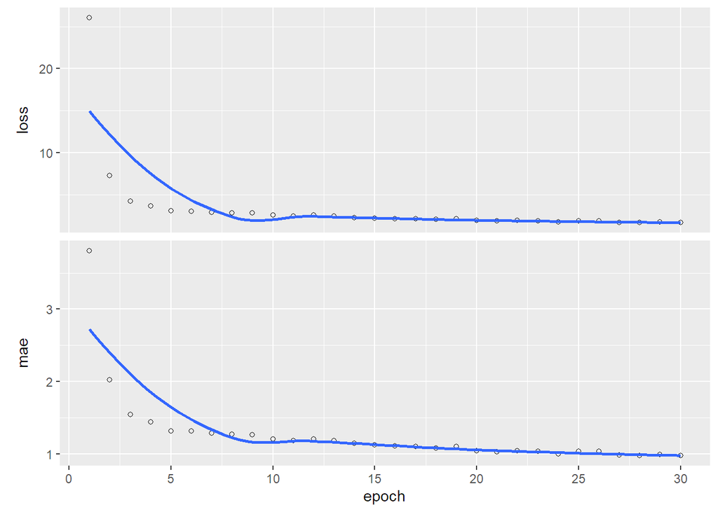

```r
bike.fulltrain <- rbind(bike.train.scale, bike.val.scale)
train.x <- as.matrix(bike.fulltrain[,-count])
train.y <- as.matrix(bike.fulltrain[,count])

best_model <- keras_model_sequential()         %>%
  layer_dense(128, activation = "tanh",            # input and first hidden layer
              input_shape = ncol(train.x))     %>%
  layer_dense(units = 32, activation = "tanh") %>% # second hidden layer
  layer_dense(units = 1, activation = "relu")      # output layer

best_model %>% compile(
  optimizer = optimizer_adam(learning_rate = 0.01),
  loss = 'mse',
  metrics = 'mae'
)

set.seed(1)

history <- best_model %>% fit(train.x, train.y, epochs = 30, batch_size = 64)
plot(history)
```

### Test Model Using Test Set

```r
set.seed(1)
test.x <- as.matrix(bike.test.scale[,-count])
test.y <- as.matrix(bike.test.scale[,count])

best_model %>% evaluate(test.x, test.y)
```

```
##     loss      mae
## 2.418201 1.148466
```

```r
predicted.nums <- best_model %>% predict(test.x)

# undo the square root
adj.predicted.nums <- predicted.nums^2
adj.test.y <- test.y^2
print(paste("RMSE: ", rmse(adj.predicted.nums, adj.test.y)))
```

```
## [1] "RMSE:  46.648225129241"
```

## Use Linear Regression Model

### Train Model

```r
library(ISLR)
lm.train <- bike.trainval
logistic_model <- lm(count~., data = as.data.frame(lm.train))

summary(logistic_model)
```

```
##
## Call:
## lm(formula = count ~ ., data = as.data.frame(lm.train))
##
## Residuals:
##      Min       1Q   Median       3Q      Max
## -12.0195  -3.0658  -0.4089   2.4467  17.1204
##
## Coefficients:
##               Estimate Std. Error t value Pr(>|t|)
## (Intercept) -3.231e+02  9.798e+00 -32.978  < 2e-16 ***
## holiday     -2.526e-02  2.769e-01  -0.091 0.927336
## workingday   2.178e-01  1.439e-01   1.514 0.130005
## weather     -1.121e+00  7.828e-02 -14.321  < 2e-16 ***
## temp        -8.624e-02  3.619e-02  -2.383 0.017178 *
## atemp        1.815e-01  3.021e-02   6.009 1.93e-09 ***
## humidity    -2.930e-03  3.038e-03  -0.964 0.334821
## windspeed   -9.627e-03  5.858e-03  -1.644 0.100308
## dayofmonth   2.236e-02  7.936e-03   2.818 0.004848 **
## year         2.999e+00  8.798e-02  34.084  < 2e-16 ***
## xmonth      -9.718e-01  1.905e-01  -5.103 3.41e-07 ***
## ymonth       3.301e-01  1.266e-01   2.608 0.009130 **
## xday         1.975e-01  8.737e-02   2.261 0.023787 *
## yday        -2.277e-01  6.765e-02  -3.365 0.000768 ***
## xhour       -3.832e+00  6.475e-02 -59.174  < 2e-16 ***
## yhour       -4.881e+00  7.692e-02 -63.456  < 2e-16 ***
## xseason      9.686e-01  1.398e-01   6.927 4.57e-12 ***
## yseason     -9.371e-01  1.368e-01  -6.852 7.72e-12 ***
## ---
## Signif. codes:  0 '***' 0.001 '**' 0.01 '*' 0.05 '.' 0.1 ' ' 1
##
## Residual standard error: 4.279 on 9781 degrees of freedom
## Multiple R-squared:  0.5949, Adjusted R-squared:  0.5942
## F-statistic: 844.9 on 17 and 9781 DF,  p-value: < 2.2e-16
```

### Test Model

```r
lm.test <- bike.test
lm.predictions <- predict(logistic_model, lm.test, type="response")
adj.lm.predictions <- lm.predictions^2
adj.lm.test.y <- lm.test$count^2
print(paste("RMSE: ", rmse(adj.lm.predictions, adj.lm.test.y)))
```

```
## [1] "RMSE:  136.16272666002"
```

### Results

The RMSE of the Linear Regression model is approximately 3 times higher than that of the ANN, at 136.1627, proving that the countless hours, blood, sweat, and tears that I put into training the neural networks for this assignment were worth the years they inevitably took off my life trying to get them working properly.